# Lecture 10: Bitcoin security

### Announcements

- Please pick up your card
- Due **Friday 10/10 at 6pm** on Gradescope
  - Reading Assessment 5, covering [NBFMG sections 2.4-3.1 and 3.4-3.5](https://d28rh4a8wq0iu5.cloudfront.net/bitcointech/readings/princeton_bitcoin_book.pdf)
  - Homework 4, on working with a toy blockchain
- If you use generative AI on the homework, then
  - Your process statement **must** contain the full prompts and responses
  - You cannot simply feed the question into the AI tool to ask for the answer
- Test 1 retry/regrade requests are due on **Tuesday 10/14 at 6pm** using Gradescope’s regrade request system

### Reminder: course grading

The syllabus describes how your overall course grade is computed.

- There are 54 test points available in this course (across 3 tests)
- There are 108 practice credits in this course (in lecture, lab, reading, and homework)
- The final exam is worth 18 points

Your *course score* is calculated as follows:

- Take the sum of your 3 test scores (the final exam can replace the lowest test)
- Add a small bonus if you complete $\geq 95$ practice credits
- Subtract a penalty if you complete $< 90$ practice credits (don’t let this happen!)
- Add your final exam score $- \, 12$. For example:
  - If you earn a final exam score of 15, you get +3 points
  - If you earn a final exam score of 9, you get -3 points

Look up the course score in this table to find the course grade.

| Course grade: | A | A- | B+ | B | B- | C+ | C | D | F |
| --- | --- | --- | --- | --- | --- | --- | --- | --- | --- |
| Course score: | $\geq 51.0$ | $\geq 45.0$ | $\geq 42.0$ | $\geq 39.0$ | $\geq 36.0$ | $\geq 33.0$ | $\geq 30.0$ | $\geq 24.0$ | $< 24.0$ |

### Learning outcomes

By the end of today’s lecture, you will learn:

- How nodes and miners can check the validity of the blockchain (and how light clients can partially check validity with some assistance from the nodes)
- How we can formally specify the consensus of blockchains using two concrete guarantees: *liveness* and *safety*

### Review from last lecture

Bitcoin is a digital currency that *does not require a single, trusted banking authority* to manage everybody’s transactions and bank balances.

- 3 types of data structures: transactions, blocks, and the entire blockchain
- 3 types of participants: light clients, nodes, and miners
- 3 types of attacks that Bitcoin stops: censorship, inconsistency, and double-spending

Bitcoin’s **proof of work** mining requires that $\texttt{SHA-256}(\texttt{block}, \texttt{nonce})$ begins with many 0 bits. The **difficulty level** is set so that the world produces a new block every 10 minutes, in expectation.

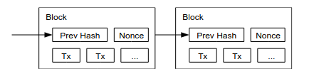

Block header and transactions (image source: [Nakamoto whitepaper](https://bitcoin.org/bitcoin.pdf))

To achieve consensus on a single blockchain, Bitcoin nodes and miners follow a simple rule:

- Always choose the **longest** valid blockchain (or more precisely, the blockchain with the most cumulative difficulty)
- As a tiebreaker, choose the chain that you heard **first**

## 10.1 Blockchain validity

Nodes and miners in Bitcoin maintain a local copy of the blockchain. We require that they check the validity of each new block that is created and gossiped around the peer-to-peer network.

Overall, here is the high-level idea of Bitcoin’s consensus algorithm (this list is adapted from [Prof. Abhishek Jain’s slides](https://www.cs.jhu.edu/~abhishek/classes/CS601-641-441-Spring2018/Lecture3.pdf)):

1. New transactions are broadcast to all nodes that happen to be online right now
2. Each miner collects new transactions into a block
3. After solving a proof of work puzzle, some miner broadcasts its block
4. All nodes check that the block is **valid** (as we will discuss momentarily)
5. Miners express their acceptance of the block through their willingness to build the next block on top of it

### Transaction validity

**Interactive question.** Suppose that you run a Bitcoin node. Which of these statements is *not* required for you to accept a Bitcoin transaction as valid?

1. The receiver(s) get no more money than the sender(s) are spending
2. Point to a previous transaction where: (a) the sender(s) actually received the money that they are now trying to spend, and (b) this transaction has not yet been spent
3. Contain a valid digital signature from everyone who is sending money
4. Contain a valid digital signature from everyone who is receiving money

*Answer*. D is incorrect. Bitcoin nodes and miners should check statements A through C.

If I show a single transaction to a light client, then

- They can check statement C on their own
- But they cannot check statements A and B because it knowledge of the **previous** transactions in the blockchain, so only *nodes* and *miners* can verify them

### Block validity

**Interactive question.** Suppose that you run a Bitcoin node. Which of these statements is *not* required for you to accept a Bitcoin block as valid?

1. Only contain transactions that are valid
2. Be produced within 10 minutes of the previous block
3. Link to blocks that are themselves valid, all the way back to the first (or “genesis”) block in the blockchain
4. Contain a winning `nonce` that satisfies the difficulty rule

*Answer*. B is incorrect. Nodes and miners must check the other statements when they hear a new block on the gossip network.

There are some other constraints in the Bitcoin software beyond the ones we discussed in this course.

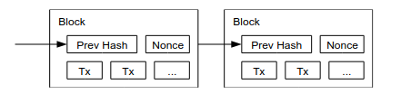

Block header and transactions (image source: [Nakamoto whitepaper](https://bitcoin.org/bitcoin.pdf))

If I hand an individual block to a *light client*, then they can check statement D on their own but not the rest. Only full *nodes* and *miners* can check the validity of all transactions and blocks, since they have stored a local copy of the entire blockchain.

## 10.2 Consensus via an honest majority assumption

If Alice sends 1 coin to Bob on the Bitcoin blockchain, then eventually:

- Bob he received 1 coin
- Bob knows that everyone else also knows that he received 1 coin
- Bob knows that they know that he knows that he received 1 coin
- and so on…

This **common knowledge** is what makes Bob confident that the rest of the world will allow him to spend the coin later. And this is true even though Bob doesn’t communicate directly with the entire world.

Bitcoin achieves this strong idea of consensus based on the following *assumption* about the world:

> The majority of the **computational power** used for mining (at any given time) is controlled by honest miners.

Here, the term “honest” means someone who runs the unmodified Bitcoin software, plays by the rules, and doesn’t try to double-spend or otherwise cheat the system. (Being greedy and selfish does not disqualify someone from being “honest,” at least in the sense that we will use the term in this course.)

- If this assumption holds, then a leader election based on proof of work (eventually) stops double-spending attacks,because a dishonest miner cannot keep up with the raw computing power of the honest majority
- On the other hand: if an attacker actually has the majority of the hash power, then they can solve proof of work puzzles faster than the honest miners and can therefore rewrite history!
- Note that this honest majority assumption is stronger than the “anytrust” assumption that one of the miners is honest, which was all that we needed to ensure censorship resistance

### Another view of forking

To see why Bitcoin needs an honest majority of computing power, let’s use the same forking picture as before, but change the scenario as follows:

- The time in the present is actually after block `D` has been posted
- A malicious miner Mallory wants to revoke a transaction that occurred in the past, in block `B`
- To do so, Mallory plans to build a fork `A` $\to$ `B2` and create enough blocks that the honest nodes switch to her chain
- In the meantime, the honest miners continue creating blocks (blissfully unaware of Mallory’s plan)

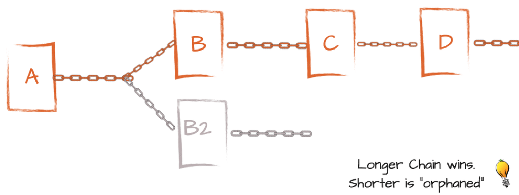

Bitcoin’s consistency rule (image source: [Mango Research](https://www.mangoresearch.co/blockchain-forks-explained/))

In essence, Mallory is in a race with the honest miners:

**Question.** Does this remind you of any type of math or statistics problem that you have seen previously? If you had to calculate the probability that Mallory ever takes the lead in this race, how would you do so?

*Answer*. This is a Markov chain problem!

[Nakamoto’s whitepaper](https://bitcoin.org/bitcoin.pdf) includes the following function (which I translated from C++ into Python). It calculates the probability that an attacker who controls a `q` fraction of the computing power of the network can execute a double-spend attack to overwrite the last `z` blocks in the blockchain.

```python
# Code adapted from the Bitcoin whitepaper at https://bitcoin.org/bitcoin.pdf

from math import exp, pow

def AttackerSuccessProbability(q: float, z: int):
    p = 1.0 - q
    poisson_lambda = z * (q / p)
    sum = 1.0
    for k in range(z+1):
        poisson = exp(-poisson_lambda)
        for i in range(1, k+1):
            poisson = poisson * poisson_lambda / i
        sum = sum - poisson * (1 - pow(q / p, z - k))
    return sum

q = 0.1
print("q =", q)
for z in range(10):
    print("z =", z, "\t  Prob =", format(AttackerSuccessProbability(q, z),"1.7f"))
print("")
q = 0.3
print("q =", q)
for z in range(0, 55, 5):
    print("z =", z, "\t  Prob =", format(AttackerSuccessProbability(q, z),"1.7f"))
```

```
q = 0.1
z = 0     Prob = 1.0000000
z = 1     Prob = 0.2045873
z = 2     Prob = 0.0509779
z = 3     Prob = 0.0131722
z = 4     Prob = 0.0034552
z = 5     Prob = 0.0009137
z = 6     Prob = 0.0002428
z = 7     Prob = 0.0000647
z = 8     Prob = 0.0000173
z = 9     Prob = 0.0000046

q = 0.3
z = 0     Prob = 1.0000000
z = 5     Prob = 0.1773523
z = 10    Prob = 0.0416605
z = 15    Prob = 0.0101008
z = 20    Prob = 0.0024804
z = 25    Prob = 0.0006132
z = 30    Prob = 0.0001522
z = 35    Prob = 0.0000379
z = 40    Prob = 0.0000095
z = 45    Prob = 0.0000024
z = 50    Prob = 0.0000006
```

This code shows that even if a dishonest miner controls 10% of all the hash computing power on the blockchain, it will only have about a 1.3% chance of succeeding at double-spending a transaction from `z = 3` blocks ago.

- The attacker can increase its chance of success by buying or renting more computational power.
- In response, defenders can resist this attack by waiting for more blocks to be confirmed in the public, honest chain.

### An example

Suppose Mallory creates a transaction that sends money to Alice. But Alice doesn’t trust the sender and wants to be 99.9% confident that her new money cannot be taken away through a double spend attack.

The Nakamoto whitepaper includes the following table that shows how many blocks Alice needs to see mined after the block containing the Mallory $\to$ Alice transaction, as a function of the dishonest miner’s computational power, so that a double-spend succeeds with at most 0.1% probability.

| Adversary’s computational power | # blocks required |
| --- | --- |
| 10% | 5 |
| 15% | 8 |
| 20% | 11 |
| 25% | 15 |
| 30% | 24 |
| 35% | 41 |
| 40% | 89 |
| 45% | 340 |

There are two important takeaways from this table:

## 10.3 Finalization

**When** does the existence of a transaction become common knowledge? Suppose that Bob sees a transaction on the Bitcoin peer-to-peer network in which Alice sends 1 coin to him.

- Bob shouldn’t immediately believe that the money is his, because the transaction isn’t in a block yet.
- Even after Bob sees the transaction in a block `B` he shouldn’t believe that the money is his, because a fork could naturally happen and this block might not wind up on the longest chain

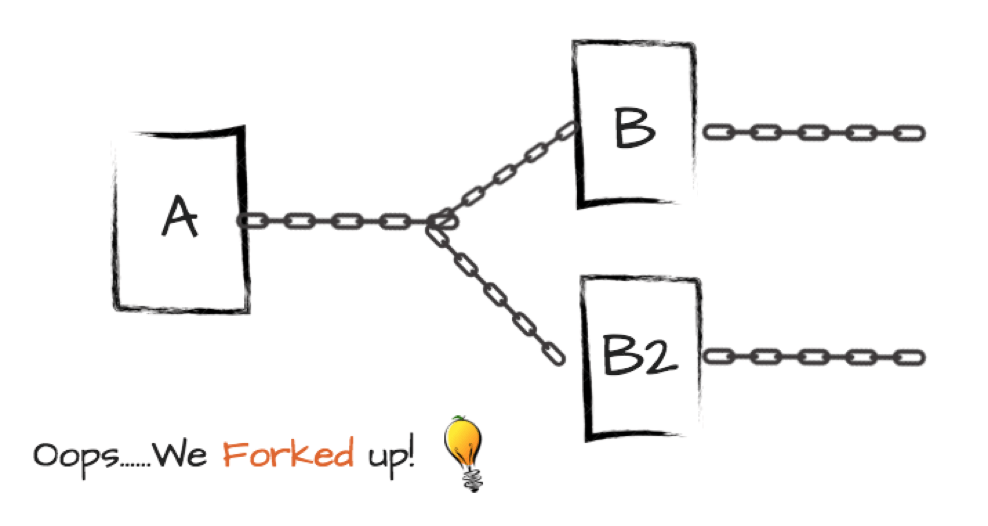

Image source: [Mango Research](https://www.mangoresearch.co/blockchain-forks-explained/)

- Even after Bob sees a few more blocks built on top of the block `B` containing his transaction, he *still* might not believe that the money is his, because Alice might be maliciously forking the chain to run a double-spend attack

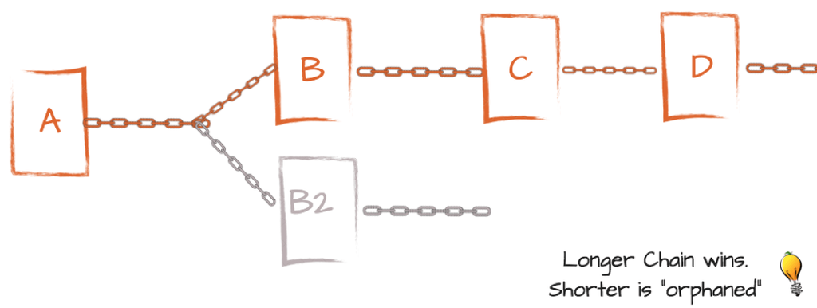

Image source: [Mango Research](https://www.mangoresearch.co/blockchain-forks-explained/)

- But surely at some point, Bob gets to believe that the money is his… right?

**Definition 1 (Finalized blocks)** A node considers a block to be *finalized* if it is at least $k$ blocks deep inside of the longest chain. Also, the node considers a transaction to be finalized if it is part of a finalized block.

In other words: a block is finalized when it becomes **common knowledge** that it will remain in the blockchain forever.

Overall, Bitcoin’s proof-of-work blockchain achieves the following security goals as long as a majority of the computing power is honest (i.e., follows the rules).

1. **Liveness**: Every transaction is eventually finalized by all honest nodes.
2. **Safety**: Honest nodes do not finalize different blocks at the same height.

Bitcoin achieves liveness and safety. The exact choice of $k$ to use depends on one’s view of:

- How much computing power the adversary has
- How low of a probability for double-spend attacks that one is willing to tolerate

As a simple heuristic, many people consider Bitcoin transactions to be finalized once they are $k = 6$ blocks deep in the blockchain. At that point, an attacker with 10% of the mining power has only probability $p = 0.0002428$ of rewriting history.

In order to achieve these goals, Bitcoin is purposely designed to be:

- *Slow*, in that transactions take awhile to become finalized
- *Bounded*, in that only a small number of transactions can be inserted in each block
- *Computationally intensive*, in order to distinguish the honest majority from the dishonest minority

## 10.4 Simplified payment verification

Note that we have not yet provided any security guarantees to the light clients, since they cannot independently validate transactions and blocks. Let’s see if we can extend *liveness* and *safety* to them.

- Remember that a light client doesn’t have the hard drive space to store the 689 GB of data in the Bitcoin blockchain
- Still though, they can periodically connect to the Internet and download some data

It would be great if we could compress all transactions into a small dataset. Unfortunately, that’s impossible. Instead, we can leverage the facts that:

1. The *nodes* know the full list of transactions, and
2. The nodes have good Internet connectivity, so they are available to provide transaction data to the light clients.

The light clients just need to verify the accuracy of the transactions – that is, to make sure that the nodes are telling them the truth.

**Interactive question.** What cryptographic primitive can we use to help the light clients?

1. Digital signatures
2. Merkle trees
3. Message commitments
4. Pseudorandomness

### Merkle trees

Recall that Merkle trees allow us to:

- Create a single hash digest that corresponds to a large collection of files $S = (f_1, f_2, \ldots, f_k)$
- Subsequently reveal any file in the set and *prove* set membership

[figure not shown]

Verifying a Merkle proof (source: Alin Tomescu, [*Decentralized Thoughts blog*](https://decentralizedthoughts.github.io/2020-12-22-what-is-a-merkle-tree/))

How does this relate to Bitcoin? Well, if you think about the transactions as “files” and the block as a collection of files, we can do something similar here.

To support light clients, we are going to make two changes to the way that Bitcoin works. The first change applies to everyone, and the second change applies only to light clients.

1. Each block will contain the Merkle root of all transactions within the block. The block itself will also contain all transactions, as before.

   We will call the **block header** as just the following items: the nonce of the current block, the root of a Merkle tree for all transactions within that block, and the pointer to the previous block’s hash. Because the Merkle root *binds* together all of the transactions, it now suffices to create a proof-of-work puzzle where the hash is only taken over the header, and not the transactions themselves.

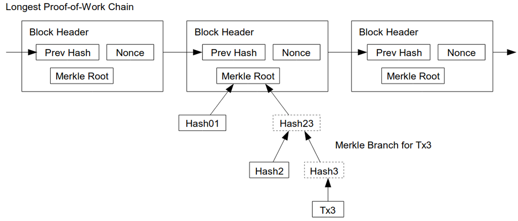

   Merkle tree in the block header (image source: [Nakamoto whitepaper](https://bitcoin.org/bitcoin.pdf))

2. A light client will follow the same rule as nodes: find the blockchain of the largest height (or more accurately, the most cumulative difficulty). But the light client only downloads the block headers, not the full blocks (i.e., they won’t know the transactions).

To give a sense of scale:

- Each header is 80 bytes in size, so downloading all block headers for Bitcoin is about 70 MB of data right now.
- This is much smaller than 689 GB for the full blocks!

With this info, a light client can:

- Verify the proof of work puzzles themselves.
- Query a full node to ask whether they have received money. That is: if the client believes it has received money in block $N$, it can ask a node to send (1) the transaction that pays its public key and (2) a Merkle proof that it is contained within the set represented by that block’s Merkle root.

Note that a light client *cannot* verify:

1. That the full block is valid (in particular, that the other transactions have valid signatures)
2. That their money hasn’t yet been spent in a subsequent block

They must rely on the nodes to perform verification check #1, and on their own memory for property #2.

This makes light clients more vulnerable to attackers than nodes. For instance, a malicious miner can just create a single “bad” block that contains invalid signatures; nodes will reject it but a light client will be fooled.

For this reason, light clients should be even more careful when **finalizing** a transaction.

Eventually though, light clients will inherit the liveness and safety guarantees from the nodes.

## 10.5 The path forward

This is all that I want to say about Bitcoin in this course. Even though Bitcoin is focused on financial transactions, think about how these ideas can be applied in general for sending messages and datasets on the Internet.

- Nobody can *censor* you from talking to your friends
- If you send a message to a large group, then everyone can *agree* about what you said (even if some people in the group are trying to cause confusion)

Importantly: agreement is possible even though the Bitcoin participants do not have a common communication channel where one person posts a message and everyone can see it.

The idea that a bunch of computers over the Internet can reach agreement in the face of an adversary is kind of amazing! It provides an elegant solution to *integrity* and *availability* problems in a variety of applications that go beyond money:

- Sending a message to your friends and making sure that all of them hear it, and that everyone has the *common knowledge* that everyone else has heard it too. This is called the **broadcast** problem.
- Conducting an election or any other decision-making process where it is important to make sure that everyone has consensus on which decision has been selected. This is called the **Byzantine agreement** problem.
- Designing a high-assurance computer server that continues to work even if some of the individual CPUs become corrupted or faulty. This is called **Byzantine fault-tolerance**.

We will talk about these applications next week.

## Appendix: Scripts on the blockchain

So far, we have said that a transaction has the form “Alice pays 1 coin to Bob.”

Actually, this is not quite true. Bitcoin allows for more complicated transactions than this.

A Bitcoin transaction is actually a computer script that looks like this.

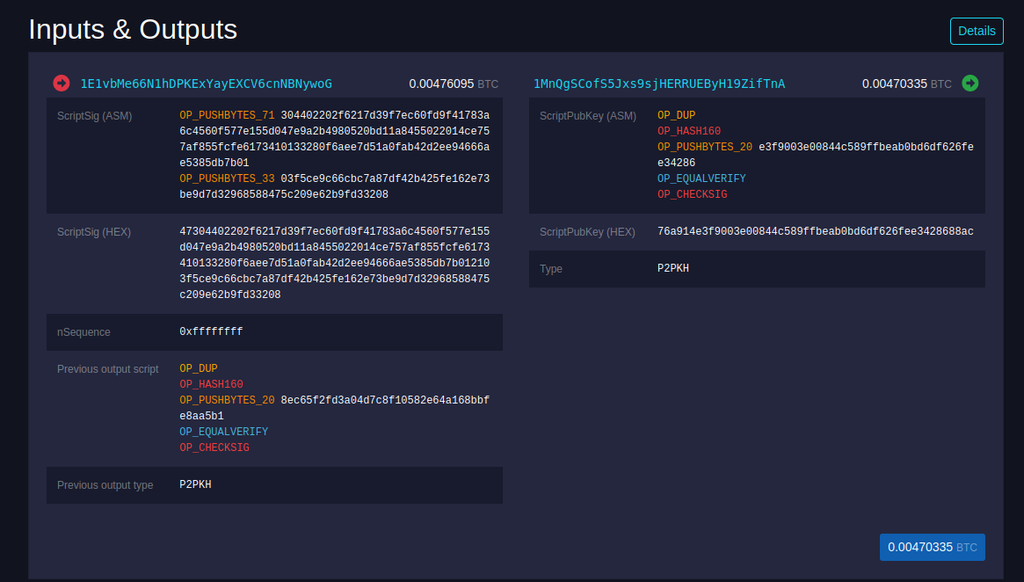

Script in a Bitcoin transaction

In words, a Bitcoin transaction involves Alice posting her own public key and the *hash of* Bob’s public key. This hash is called Bob’s wallet “address.” The transaction can be thought of as a computer program that says:

> “For anyone who shows up later with a public key and claims to be the recipient of this transaction, take the hash of their public key and check if it equals `8ec...b1`. If so, give my coins to that person.”

In fact, there are several valid operations that can be performed in a Bitcoin transaction. However, the scripting language is not Turing-complete; that is, you can’t write any computer program.

Relatedly, this is why some Bitcoin transactions take up more space than others: they can be more complicated computer programs.

[figure not shown]

Transaction sizes in a Bitcoin block

### Ethereum

Ethereum is another cryptocurrency. It was created in 2013 – so, four years after Bitcoin, but still awhile ago. Ethereum takes the idea of scripting much further than Bitcoin does.

The Ethereum blockchain is essentially a global computer where everyone agrees on the state of this computer. The global state is replicated on all nodes that are in the Ethereum network. The Ethereum state can only be changed by users issuing transactions.

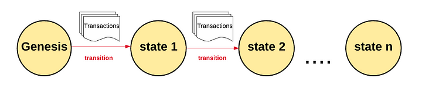

Source: [Preethi Kasireddy’s blog post](https://preethikasireddy.medium.com/how-does-ethereum-work-anyway-22d1df506369)

**Similarities.** Ethereum shares several features in common with Bitcoin, such as:

- a peer-to-peer network that connects users,
- a consensus algorithm to agree on state updates, and
- using cryptographic primitives like digital signatures and hashes.

Additionally, Ethereum also has its own digital currency, known as Ether.

Just like Bitcoin transactions:

- Ethereum transactions are grouped into blocks and broadcasted into the network.
- Any person can use the global computer by issuing transactions and paying the required fees in its Ether currency.
- Every few seconds a leader gets elected, and that leader chooses which transactions go in the next block.

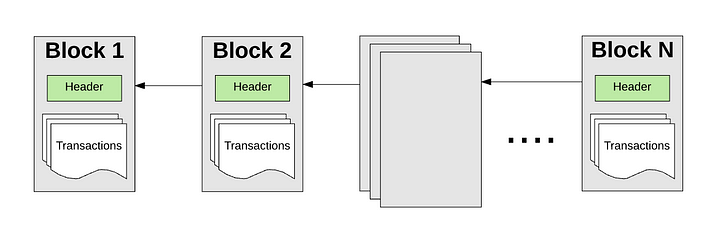

Source: [Preethi Kasireddy’s blog post](https://preethikasireddy.medium.com/how-does-ethereum-work-anyway-22d1df506369)

**Differences.** However, Ethereum’s primary objective is not to function as a digital currency payment network, and Ether is not intended to be a conventional currency. Instead,

- Ether is designed to be a utility currency that pays for the use of the Ethereum world computer.
- Transactions on the Ethereum blockchain explain how to move from one state of the machine to the next.

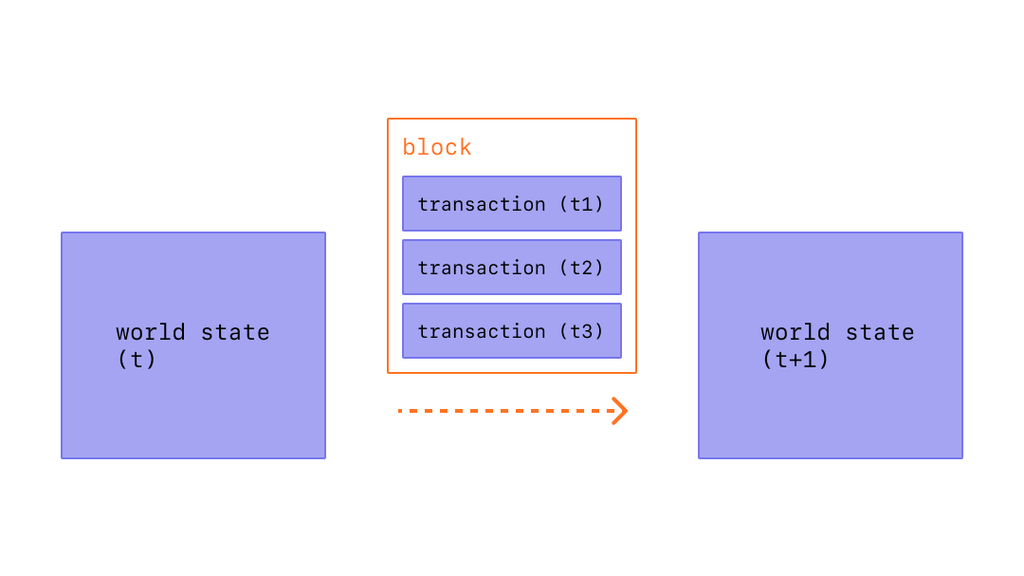

Source: [Ethereum docs](https://ethereum.org/en/developers/docs/blocks/)

Also, Ethereum’s scripting language is Turing-complete, unlike the one in Bitcoin. So, it can operate as a general-purpose computer and execute code with more complexity.

You can think of Ethereum as a state machine. Ethereum’s state is a large data structure which holds not only all accounts and balances, but a machine state, which can change from block to block according to a pre-defined set of rules, and which can execute arbitrary machine code.

The specific rules of changing state from block to block are defined by the Ethereum Virtual Machine (EVM). Every transaction causes the EVM to run which causes the global state to change. The order of the transaction is very important! The EVM is single threaded.

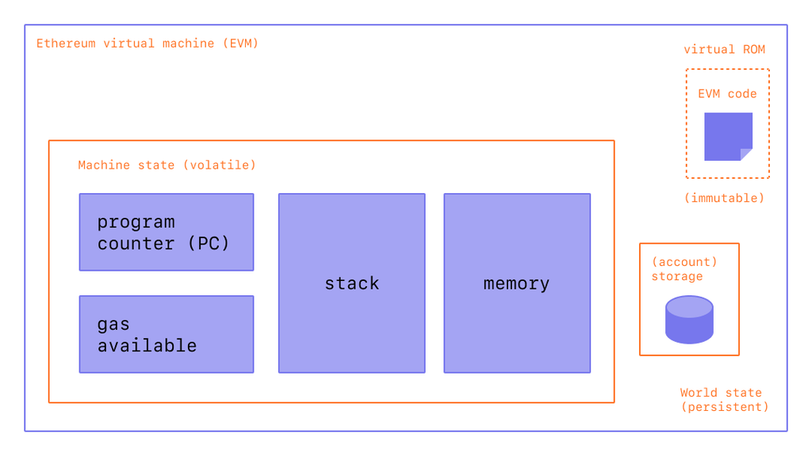

Source [Ethereum docs](https://ethereum.org/content/developers/docs/evm/evm.png)

### Smart Contracts

Why use a bunch of computers in order to create one global computer?

One benefit is that you can write software that makes and enforces financial decisions. In other words, you can create a **contract** that can be enforced via computer code.

For example, you could post a Sudoku puzzle to Ethereum and create a smart contract that says:

> “I will pay 1 coin to the first person who posts a solution to the Sudoku puzzle in the next hour. Otherwise, I will reclaim my money.”

You must currently own 1 coin for this smart contract to be valid. If so, your coin is “locked” in the smart contract until it gets paid out (either to the puzzle-solver, or back to you).

The smart contract itself must be written as a computer program. Ethereum supports several programming languages; a popular one is a language called `Solidity` that was developed for Ethereum. Solidity is an object oriented imperative programming language with a syntax similar to Python and C++.

Going one step further: you can even create new coins on top of Ethereum!

- Ethereum contains a standard interface for fungible tokens on the Ethereum blockchain, called **ERC20**. It is a set of rules that define how a token contract should behave and interact with other contracts and wallets on the Ethereum network.
- For instance, you could create a new kind of coin called `Sudokoin` and say that anyone who solves a Sudoku puzzle earns 1 `Sudokoin`. [Here](https://github.com/sudokoin/sudokoin/blob/master/sudokoin.sol) is open-source Solidity code to do exactly this! (Whether or not this coin has any value is a different matter…)

If you think that the idea of blending “computer code” with “irreversible financial transactions” can lead to disaster, then *you would be right*!

Bugs in Ethereum smart contracts can lead to your money being sent to the wrong place, or being locked forever. For this reason, smart contracts should always be (and sometimes are) carefully checked by human code reviewers and formally verified by computers.